# Chapter 6

shinya suzuki

2016年11月22日

# Chapter6 GLMの応用範囲を広げる

GLMの３つの設定を再確認

- 応答変数の確率分布
  - 二項分布
  - ロジスティック分布
  - ガンマ分布
- 線形予測子(説明変数の組み合わせ)
  - 交互作用
  - オフセット項
- リンク関数(応答変数の確率分布と, 線形予測子の関係)
  - 対数関数

６章では次の３つに着目

- 二項分布ロジスティック回帰
- オフセット項
- ガンマ回帰

## 6.2 上限のあるカウントデータ

上限のあるカウントデータの場合には, 二項分布が一般的である.

まずは, データをプロットして傾向を確認する. グラフから, xによって生存種子数は増えそうで, 肥料有りでも 生存種子数が増えそうなことがわかる.

```r
path   <- "../../最新版/kubobook2012/chapter06/binomial/data4a.csv"
obs    <- read_csv (path)
```

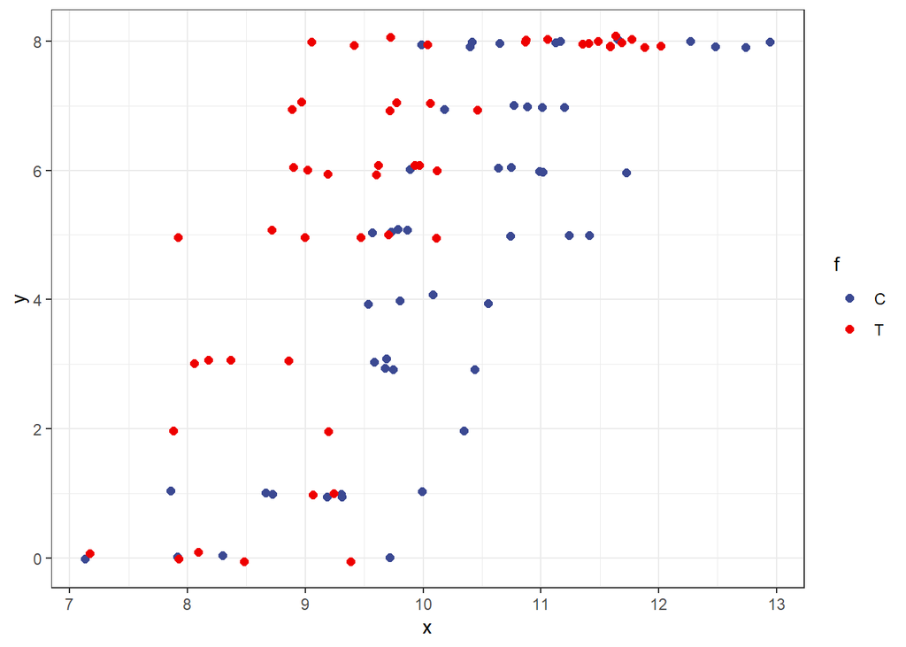

```r
obs %>%
    ggplot(aes(x, y)) +
    geom_jitter(aes(colour=f), width=1., height=.1, size=2)+
    scale_color_aaas() +
    theme_bw()
```

## 6.3 二項分布で表現する「あり・なし」カウントデータ

２項分布の確率分布の式は次のとおり.

$$p(y | N, q) = \binom{N}{y}q^y(1-q)^{N-y}$$

$N=8$の場合(今回の問題設定)の, 二項分布の形状をいくつか見てみる.

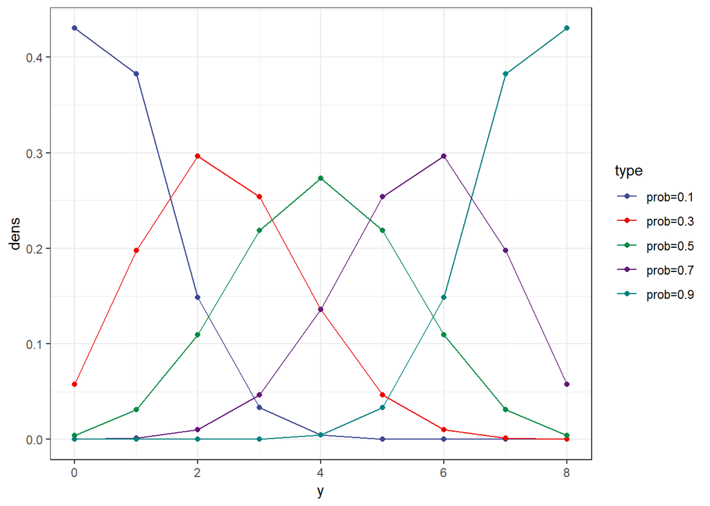

```r
size <- 8
ps   <- seq(.1, .9, .2)
D    <- lapply (ps, function (p) {
    d <- data_frame (
        y = 0:size
        , dens = dbinom(y, size, p)
        , type = paste0("prob=", p)
    )
    d
}) %>%
    bind_rows()
D %>%
    ggplot(aes(y, dens, group=type, colour=type), size=2) +
    geom_line() +
    geom_point() +
    scale_color_aaas()+
    theme_bw()
```

## ロジスティック回帰とロジットリンク関数

ここではロジットリンク関数を用いる. ロジットリンク関数は $q$について解くと, 線形予測子を引数としたロジスティック分布関数になる.

$$\textrm{logit}(q) = \log \frac{q}{1-q} = \sum\beta_ix_i$$
$$q=\frac{1}{1+\exp(-\sum\beta_ix_i)}$$

ロジスティック関数の挙動を確認する. まず, 単なるロジスティック関数について.

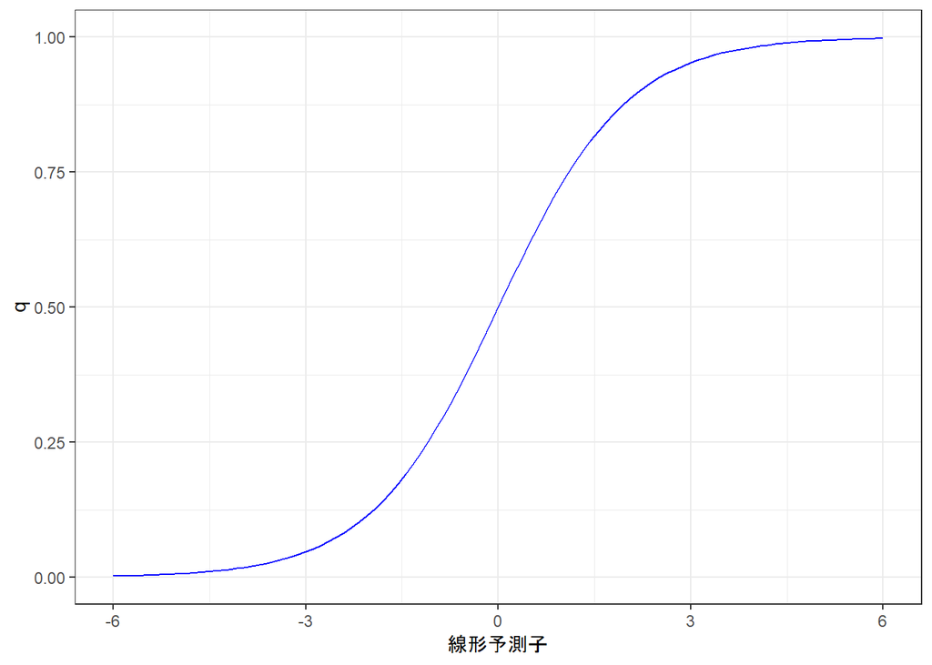

```r
logistic <- function(x) {1 / (1 + exp (-x))}
stat_fun <- stat_function (fun=logistic, colour="blue")

data_frame(x = c(-6, 6)) %>%
ggplot() +
    stat_fun +
    theme_bw() +
    xlab("線形予測子") +
    ylab("q") +
    xlim(c (-6, 6)) +
    ylim(c (0, 1))
```

定数項の上下は関数系のシフトになる.

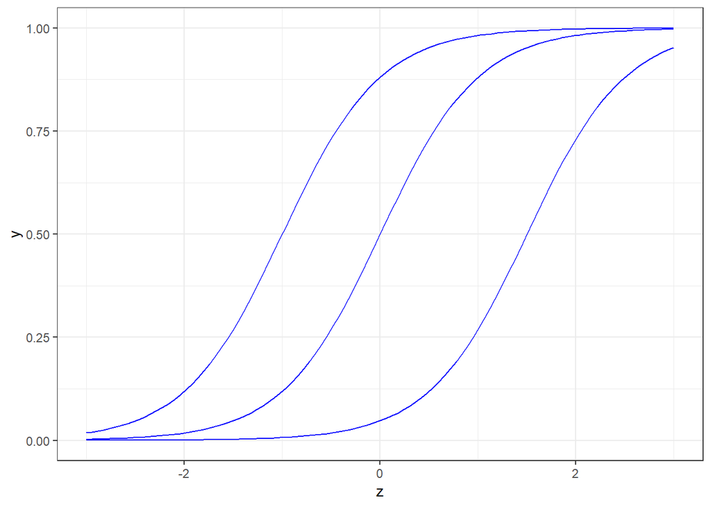

```r
generator_logit <- function (beta1) {
    function (x) {
        linpred <- beta1 + 2 * x
        return (1 / (1 + exp (-linpred)))
    }
}
logits <- lapply (c(-3, 0, 2), generator_logit) %>%
          lapply (function(x) stat_function(fun=x, colour="blue"))
base   <- data_frame(
    x = c(-3, 3)
) %>%
    ggplot(aes(x)) +
    theme_bw() +
    xlab("z")
Reduce("+", logits, init = base)
```

$x$の係数は関数の上がり方に効果がある.

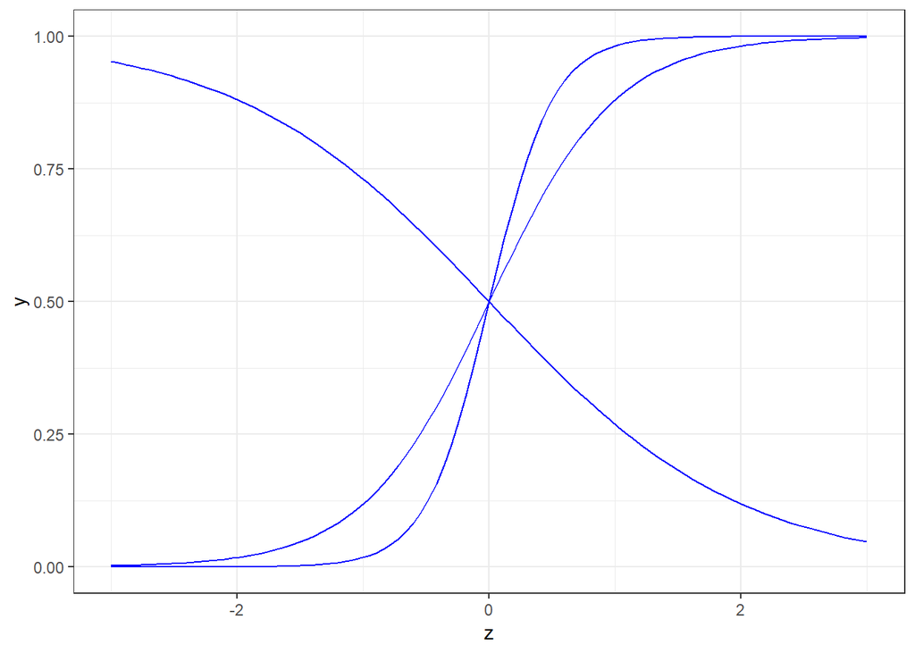

```r
generator_logit <- function (beta2) {
    function (x) {
        linpred <- beta2 * x
        return (1 / (1 + exp (-linpred)))
    }
}
logits <- lapply (c(-1, 2, 4), generator_logit) %>%
          lapply (function(x) stat_function(fun=x, colour="blue"))
base   <- data_frame(
    x = c(-3, 3)
) %>%
    ggplot(aes(x)) +
    theme_bw() +
    xlab("z")
Reduce("+", logits, init = base)
```

### Rでパラメータを推定

ここまでで, 応答変数の確率分布と線形予測子, そしてリンク関数を設定・確認できたので 後はパラメータを推定すればよいだけである.

パラメータは尤度関数を設定することから始まる. この尤度関数をみると$N$は一定でなくてもよいようだ.

$$L(\{\beta_i\}) = \Pi_i\binom{N_i}{y_i}q_i^{y_i}(1-q_i)^{N_i-y_i}$$

対数尤度関数は次となる.

$$\log L(\{\beta_i\}) = \sum_i\{\log \binom{N_i}{y_i} + y_i\log q_i + (N_i-y_i)\log (1-q_i)\}$$

パラメータ推定はあっさりとできる.

```r
fit <- glm (cbind(y, N-y) ~ x + f, data = obs, family = binomial)
```

推定結果を回帰結果に重ねたグラフを描く.

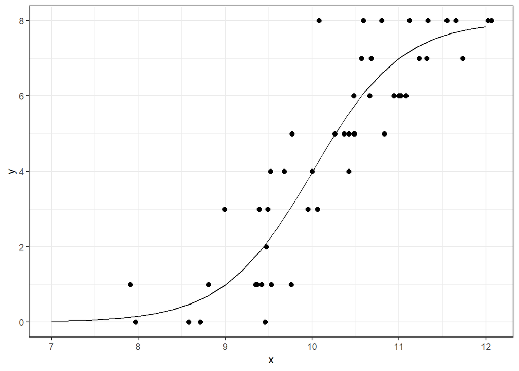

```r
d        <- data_frame(x=seq(7, 12, by=.2), f = "C")
glm_pred <- 8 * predict (
    fit
    , newdata = d
    , type="response"
)
d$y      <- glm_pred
d %>%
    ggplot(aes(x, y)) +
    geom_line() +
    geom_point(data=filter(obs, f == "C"), aes(x, y), size=2, shape=19) +
    theme_bw()
```

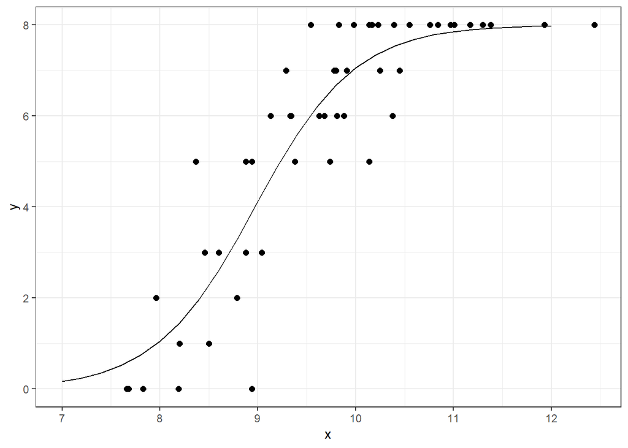

```r
d        <- data_frame(x=seq(7, 12, by=.2), f = "T")
glm_pred <- 8 * predict (
    fit
    , newdata = d
    , type="response"
)
d$y      <- glm_pred
d %>%
    ggplot(aes(x, y)) +
    geom_line() +
    geom_point(data=filter(obs, f == "T"), aes(x, y), size=2, shape=19) +
    theme_bw()
```

### モデル選択

緑本では`MASS::stepAIC`で実行しているが, ここでは`broom`の練習も兼ねて 自力で実行してみる. ここでの`deviance`として出力されるのは残差逸脱度である.

```r
## full model以外の検討
models <-
    tibble(
        name    = c ("fixed", "x", "f", "x+f", "x*f"),
        formula = c (
            "cbind(y, N-y) ~ 1",
            "cbind(y, N-y) ~ x",
            "cbind(y, N-y) ~ f",
            "cbind(y, N-y) ~ x+f",
            "cbind(y, N-y) ~ x+f+x:f"
        )
    ) %>%
    group_by (name, formula) %>%
    do (
        fit = glm(.$formula, data=obs, family=binomial)
    )
models %>%
    glance (fit)
```

| name | formula | null.deviance | df.null | logLik | AIC | BIC | deviance | df.residual |
| --- | --- | --- | --- | --- | --- | --- | --- | --- |
| f | cbind(y, N-y) ~ f | 499.2321 | 99 | -316.8799 | 637.7598 | 642.9701 | 490.5825 | 98 |
| fixed | cbind(y, N-y) ~ 1 | 499.2321 | 99 | -321.2047 | 644.4093 | 647.0145 | 499.2321 | 99 |
| x | cbind(y, N-y) ~ x | 499.2321 | 99 | -180.1727 | 364.3454 | 369.5558 | 217.1682 | 98 |
| x*f | cbind(y, N-y) ~ x+f+x:f | 499.2321 | 99 | -132.8053 | 273.6106 | 284.0313 | 122.4334 | 96 |
| x+f | cbind(y, N-y) ~ x+f | 499.2321 | 99 | -133.1056 | 272.2111 | 280.0266 | 123.0339 | 97 |

```r
## ungroup をしてしまうと期待どおりの動作にならないことに注意
evaluation_models <-
    models %>%
    glance (fit)

## full model
evaluation_full_model <- tibble (
    name    = "full",
    formula = "y/N",
    null.deviance = NA,
    df.null = NA,
    deviance = NA,
    df.residual =  NA,
    logLik  = sum (with (obs, {dbinom(y, N, y/N, log=TRUE)}))
) %>%
    mutate (
        AIC = -2 * logLik + 2 * 100,
        BIC = -2 * logLik + 100 * log(100)
    )

res <-
    bind_rows(
        evaluation_models,
        evaluation_full_model
    )
knitr::kable(res)
```

| name | formula | null.deviance | df.null | logLik | AIC | BIC | deviance | df.residual |
| --- | --- | --- | --- | --- | --- | --- | --- | --- |
| f | cbind(y, N-y) ~ f | 499.2321 | 99 | -316.87988 | 637.7598 | 642.9701 | 490.5825 | 98 |
| fixed | cbind(y, N-y) ~ 1 | 499.2321 | 99 | -321.20467 | 644.4093 | 647.0145 | 499.2321 | 99 |
| x | cbind(y, N-y) ~ x | 499.2321 | 99 | -180.17272 | 364.3454 | 369.5558 | 217.1682 | 98 |
| x*f | cbind(y, N-y) ~ x+f+x:f | 499.2321 | 99 | -132.80530 | 273.6106 | 284.0313 | 122.4334 | 96 |
| x+f | cbind(y, N-y) ~ x+f | 499.2321 | 99 | -133.10556 | 272.2111 | 280.0266 | 123.0339 | 97 |
| full | y/N | NA | NA | -71.58862 | 343.1772 | 603.6943 | NA | NA |

## 6.5 交互作用項が入った線形予測子

交互作用項を考える. 交互作用項を考えることで, $x$の単位変化量が変わってくる. 交互作用項を入れることで複雑なモデルを考えることができるが, どの説明変数を用いるかという**組み合わせ爆発**が起きるので むやみやたらに入れないことが重要.

また, 適当に入れてもAICがよくなることが 多くあるので気をつけること.

## 6.6 割算値のモデリングはやめよう

ポアソン回帰を例に考える.

- ポアソン分布
- 対数リンク関数
- オフセット項を入れた線形予測子

考えるモデルは次. $\log(A_i)$に係数が聞いていないのがポイント.

$$\lambda_i = \exp(\beta_1 + \beta_2 x_i + \log(A_i))$$

まずは, データを表示してみる.

```r
path <- "../../最新版/kubobook2012/chapter06/binomial/data4b.csv"
obs  <- read_csv (path)
```

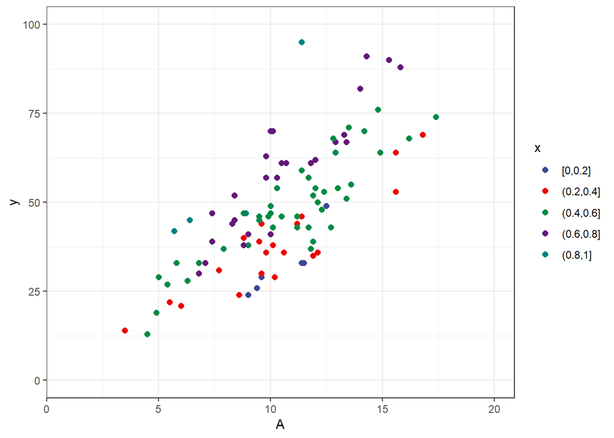

```r
obs_graph <-
    obs %>%
    mutate(x = cut(x, breaks=seq(0, 1, .2), include.lowest=TRUE)) %>%
    ggplot(aes(A, y)) +
    geom_point (aes(colour=x), size=2)+
    scale_color_aaas() +
    theme_bw() +
    xlim (c(0, 20)) +
    ylim (c(0, 100)) + scale_x_continuous(expand=c (0, 3.5))
obs_graph
```

Rでパラメータ推定をしてみる.

```r
fit <- glm (y ~ x, offset = log(A), family=poisson, data=obs)
```

推定結果をグラフに載せる.

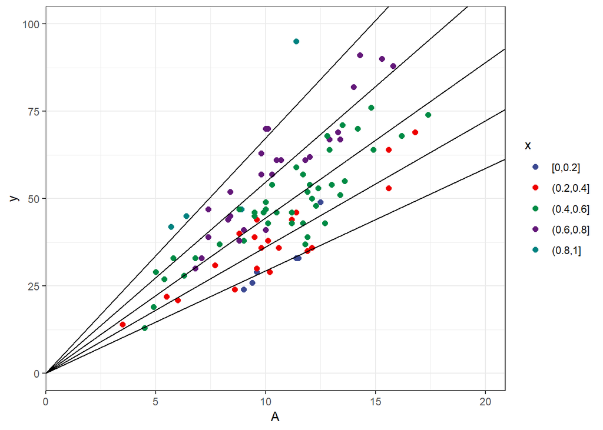

```r
xs     <- seq (.1, .9, .2)
slopes <- lapply (xs, function (x) {
    ests <- tidy(fit)$estimate
    exp (ests[1] + ests[2] * x)
})
ablines <- lapply(slopes, function(s) {
    geom_abline(intercept=0, slope=s)
})
Reduce ("+", ablines, init=obs_graph)
```

## 6.7 正規分布とその尤度

連続関数での尤度関数.

- 確率密度で作成する場合, 確率で作成する場合がある
- 確率密度の場合には対数尤度が負の値とは限らない
- 標準偏差$\sigma$を固定した場合には最小二乗法と一致する

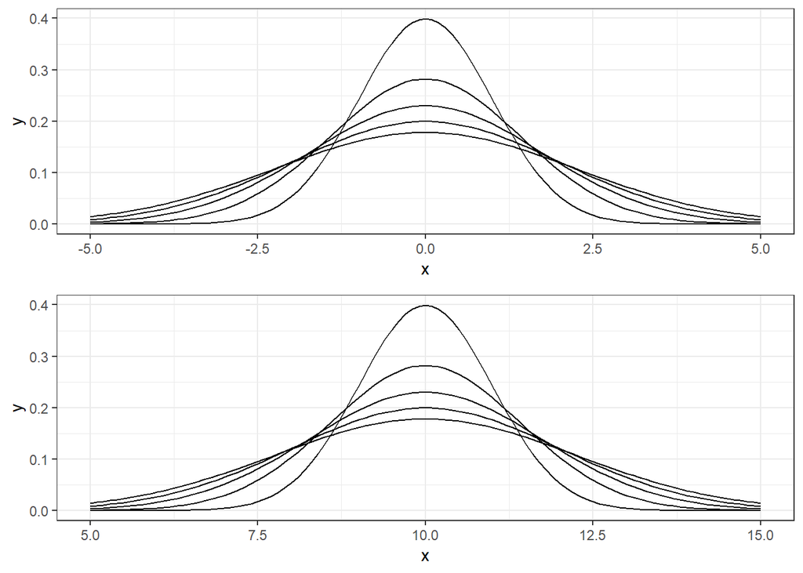

```r
## 正規分布の形状を確認する
## ポイントは平均値と分散が独立で, 平均値から左右対象
## 分散を1, 2, 3, 4, 5としている
parameters <-
    data_frame(
        mean = rep(c(0), each=5),
        sd   = sqrt(rep(1:5, each=1))
    ) %>%
    transpose()
stat_funs <-
    lapply(parameters, function(f) stat_function(fun=dnorm, args=f))
stat_funs2 <-
    lapply(parameters, function(x) {x$mean <- x$mean + 10; x}) %>%
    lapply(function(f) stat_function(fun=dnorm, args=f))
graph <- ggplot(data_frame(x=c(-20,20)), aes(x)) + theme_bw()
grid.arrange(
  Reduce ("+", stat_funs,  init=graph) + xlim(c(-5,5)),
  Reduce ("+", stat_funs2, init=graph) + xlim(c(5,15))
)
```

## 6.8 ガンマ分布でGLM

データを確認する

```r
path <- "../../最新版/kubobook2012/chapter06/gamma/kafun.csv"
obs  <- read_csv (path)
```

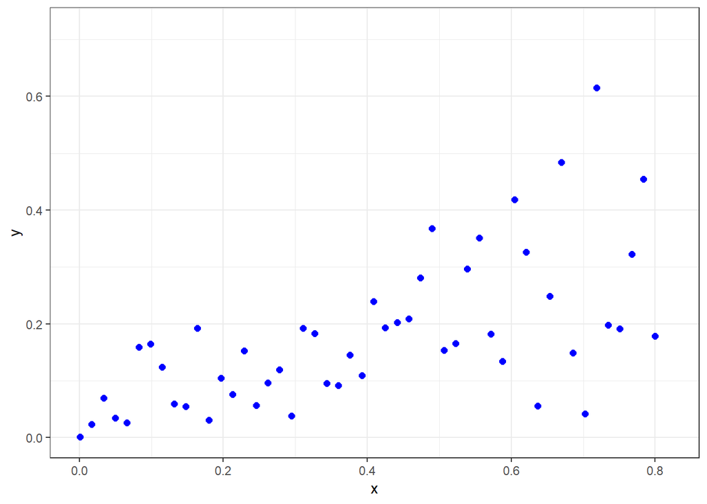

```r
obs_graph <-
    ggplot() +
    geom_point(data=obs, aes(x,y), size=2, colour="blue") +
    theme_bw()+
    xlim(c(0, .82)) +
    ylim(c(0, .72))
obs_graph
```

ガンマ分布の形状を確認する

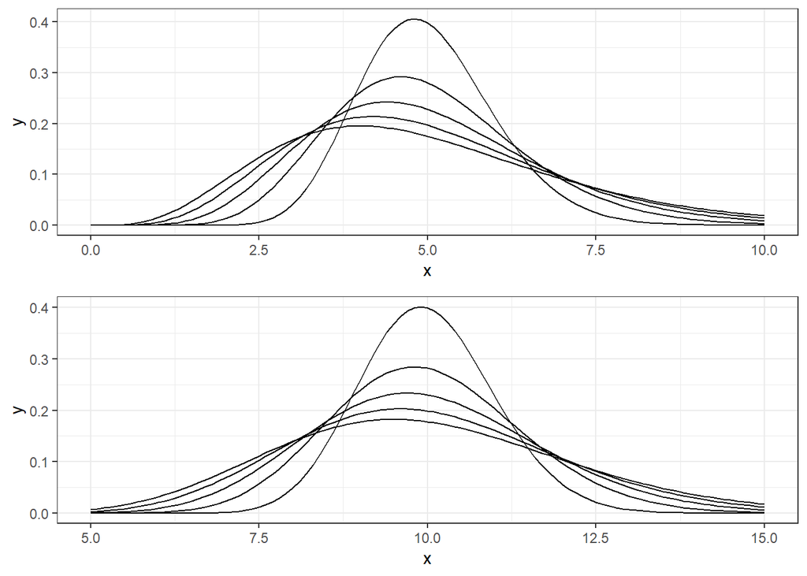

```r
parameters <-
    data_frame(
        mean   = rep(c(5, 10), each=5),
        sigma2 = rep(1:5, times=2)
    ) %>%
    mutate (
        rate  = mean / sigma2,
        shape = mean * rate
    ) %>%
    transpose()
generate_stat_funs <- function(m) {
    lapply(
        keep(parameters, function(x) x$mean == m),
        function(f) {
            args <- f[c ("rate", "shape")]
            stat_function(fun=dgamma, args=args)
        })
}
graph <- ggplot(data_frame(x=c(0,20)), aes(x)) + theme_bw()
grid.arrange(
  Reduce ("+", generate_stat_funs(5),  init=graph) + xlim(c(0,10)),
  Reduce ("+", generate_stat_funs(10), init=graph) + xlim(c(5,15))
)
```

Rでなら細かいことを考えることなく, パラメータを推定することが可能となる. … といいつつ, 平均値が決まるだけで$alhpa$や$beta$を推定しているわけではない?

予測分布を計算する**dispersion**パラメータというものから可能であるらしいが, 詳しいことはよくわからない…. 久保先生[HP](http://hosho.ees.hokudai.ac.jp/~kubo/ce/GlmGamma.html)を参照した

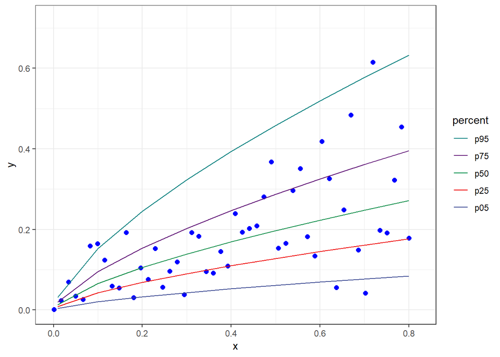

```r
fit       <- glm (y ~ log(x), family = Gamma(link="log"), data=obs)
qgamma_with_fit <- (function(fit) {
    phi         <- summary(fit)$dispersion
    function(x, p) {
        d <- data_frame(x = x)
        v <- predict(fit, d, type="response")
        rate  <- 1 / v / phi
        shape <- v * rate
        qgamma(p, shape= shape, rate =rate)
    }
})(fit)
dist   <-
    data_frame(
        x = c (.01, 1:8/10)
    ) %>%
    mutate (
        p95 = qgamma_with_fit(x, .95),
        p75 = qgamma_with_fit(x, .75),
        p50 = qgamma_with_fit(x, .50),
        p25 = qgamma_with_fit(x, .25),
        p05 = qgamma_with_fit(x, .05)
    ) %>%
    gather (percent, value, -x)
obs_graph +
    geom_line(data = dist, aes(x, value, group=percent, colour=percent)) +
    scale_color_aaas() +
    guides(colour=guide_legend(reverse=TRUE))
```